# Analysis of Relationship between Outdoor Air Pollution and Childhood Asthma Rate in New York State

https://github.com/dwitiib/BagadiaZhang_ENV872_EDA_FinalProject.git

Dwiti Bagadia and Yue Zhang

## 0.1 List of Tables

## 0.2 List of Figures

# 1 Rationale

Over the past decade air pollution has emerged as to be one of the most serious environmental threats to the world’s urban population. Studies over the years have reported the adverse health impacts of air pollution particles on people of all ages. Exposure to common urban air pollutants is associated with numerous adverse health effects, including respiratory and cardiovascular diseases, asthma exacerbation, reduced lung function and premature death. Asthma is one of the most common health problems in all age groups worldwide. Airborne pollutants may influence the symptoms of asthma patients. Asthma is a burden on communities, with significant public health and financial consequences. American Lung Association reported that New York City ranked 14th for ozone pollution among all cities in the U.S. Therefore, by studying data in New York State, we will have a better understanding of the relationship between asthma rate and air quality.

Scope: We chose to look at data in New York State from 2018 to 2020 as this is the most recent data and there will be more observation counts rather than a single city.

## 1.1 Research Question

**Question 1**: Is there a relationship between air quality and asthma rate in New York State between 2018 and 2020?

**Question 2**: Is there a relationship between non-White population density and asthma rate in New York State between 2018 and 2020?

# 2 Dataset Information

We got the asthma data from New York State’s Department of Health. This data is the most recent data by county which aggregates the emergency visit rate per 10,000 people from 2018 to 2020. Air quality data is from EPA website. We chose annual AQI summary for AQI information and daily summary data for pollutants information. Demographic data is from Social Explorer, it is a 5-year estimated data from American Community Survey.

Table 1: Data Acquisition

| Name | Data Source |
| --- | --- |
| New York State Asthma Data by County | https://webbi1.health.ny.gov/SASStoredProcess/guest?_program=/EBI/PHIG/apps/asthma_dashboard/ad_dashboard&p=mp&ind_id=ad4%20&cos=1 |
| New York State Demographic Data by County | https://www.socialexplorer.com/explore-tables |
| Annual AQI Summary Data and Daily Summary Data | https://aqs.epa.gov/aqsweb/airdata/download_files.html#Daily |

# 3 Data Wrangling

Since children are among the most vulnerable to health issues associated with ozone pollution, we selected the children that aged 0 to 17 years emergency visit rate which is the emergency visit counts divided by average population. Also, we focused on non-White population density which is the number of total population minus White alone then divided by land area as racial and ethnic minority groups “continue to bear disproportionate hardship in managing asthma”. For the annual AQI summary dataset, we first selected New York State’s data, and calculated “bad days” rate. An AQI “good day” is a day when the AQI level of concern is measured to be less than or equal to 50. Therefore, we define an AQI “bad day” as a day when the AQI was greater than 50. After that, we combined the AQI dataframes together to calculate the mean bad days rate from 2018 to 2020. For air pollutants, we first selected New York State’s data, then group it by county to gain the mean pollutant AQI. All cleaned datasets were saved into the processed folder. After all fo these steps were taken the data was considered to be wrangled and was then ready for initial visualizations.

# 4 Exploratory Analysis

The exploratory analysis of the data includes visualizing the relationship between asthma rate and air quality, as well as the relationship between asthma rate and non-White population density. We first join processed datasets together, then plot the initial visualizations of these two relationships. Both graphs show a clear trend line. To test whether there are correlations, the following linear regression analysis was conducted.

The following graph visualizes the possible relationship between asthma rate and air quality. It shows a potential trend that with the increasing bad days rate, the emergency visit rate increases.

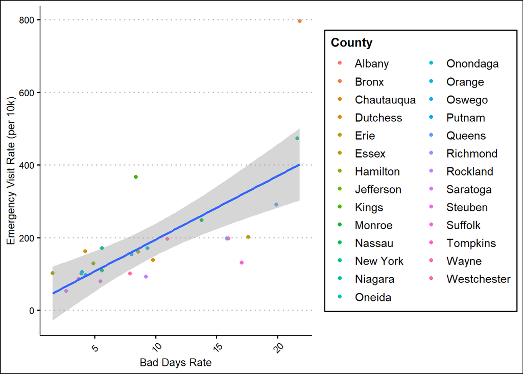

Figure 4.1: Asthma Rate by Bad Days Rate

The following graph visualizes the possible relationship between asthma rate and non-White population density. However, there are too many counties have approximate non-White population density and a few counties have high asthma rate or high non-White population density.We need a linear model to show whether there is a coorelation between these two variables.

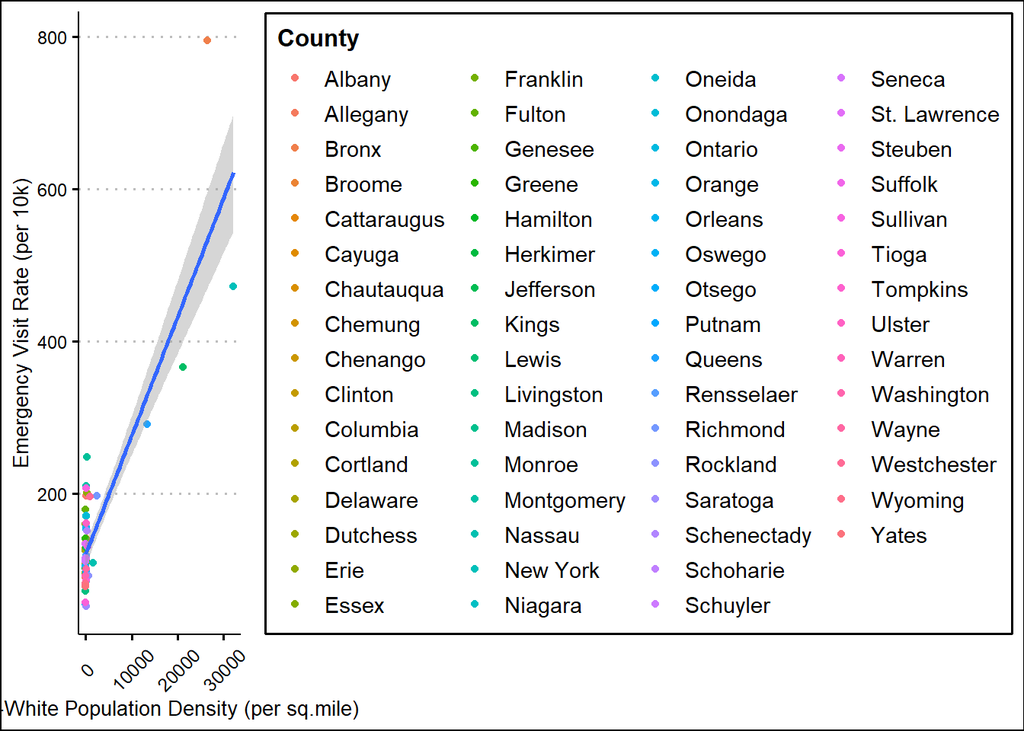

Figure 4.2: Asthma Rate by Non-White Population Density

# 5 Linear Regression

### 5.0.1 Linear Model for Asthma Rate and Air Quality

First of all, we generated a simple linear model to test the relationship between asthma rate and air quality. The following figure shows the summary plot of this initial linear model. This model is poorly fitted as there are drastic residuals asymmetry from side to side. Therefore, a log scale was applied to both the y-axis and x-axis in order to help linearize the relationship and improve the model’s fit as well as reduce the impact of extreme values.

```
##
## Call:
## lm(formula = VisitRate ~ BadDaysRate, data = NY_Asthma_AQ_join)
##
## Residuals:
##     Min      1Q  Median      3Q     Max
## -187.88  -54.36   -9.19   19.95  394.35
##
## Coefficients:
##             Estimate Std. Error t value Pr(>|t|)
## (Intercept)   18.971     40.604   0.467    0.644
## BadDaysRate   17.543      3.564   4.922 4.56e-05 ***
## ---
## Signif. codes:  0 '***' 0.001 '**' 0.01 '*' 0.05 '.' 0.1 ' ' 1
##
## Residual standard error: 110.7 on 25 degrees of freedom
## Multiple R-squared:  0.4922, Adjusted R-squared:  0.4719
## F-statistic: 24.23 on 1 and 25 DF,  p-value: 4.557e-05
```

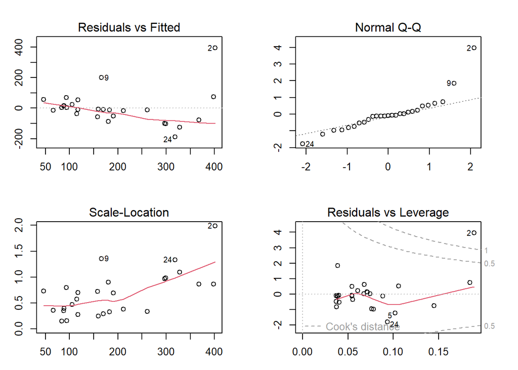

Figure 5.1: Summary Plot of Asthma Rate by Air Quality

```
##
## Call:
## lm(formula = log(VisitRate) ~ log(BadDaysRate), data = NY_Asthma_AQ_join)
##
## Residuals:
##      Min       1Q   Median       3Q      Max
## -0.65593 -0.22222 -0.02429  0.10957  1.00120
##
## Coefficients:
##                  Estimate Std. Error t value Pr(>|t|)
## (Intercept)        3.7736     0.2526  14.939 5.75e-14 ***
## log(BadDaysRate)   0.6179     0.1164   5.311 1.67e-05 ***
## ---
## Signif. codes:  0 '***' 0.001 '**' 0.01 '*' 0.05 '.' 0.1 ' ' 1
##
## Residual standard error: 0.4088 on 25 degrees of freedom
## Multiple R-squared:  0.5301, Adjusted R-squared:  0.5113
## F-statistic: 28.21 on 1 and 25 DF,  p-value: 1.671e-05
```

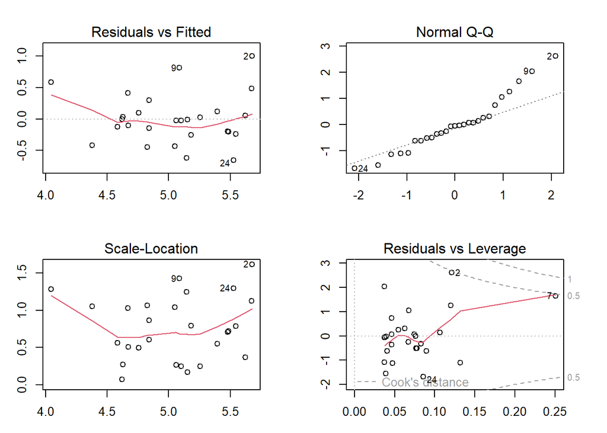

Figure 5.2: Log-transformed Summary Plot of Asthma Rate by Air Quality